# sumativa1

```python
# Imports necesarios.
import matplotlib.pyplot as plt
import seaborn as sns
import pandas as pd
```

```python
# Base de datos local
data = sns.load_dataset("car_crashes")
data.head() # Cabecera de los datos.
```

|  | total | speeding | alcohol | not_distracted | no_previous | ins_premium | ins_losses | abbrev |
| --- | --- | --- | --- | --- | --- | --- | --- | --- |
| 0 | 18.8 | 7.332 | 5.640 | 18.048 | 15.040 | 784.55 | 145.08 | AL |
| 1 | 18.1 | 7.421 | 4.525 | 16.290 | 17.014 | 1053.48 | 133.93 | AK |
| 2 | 18.6 | 6.510 | 5.208 | 15.624 | 17.856 | 899.47 | 110.35 | AZ |
| 3 | 22.4 | 4.032 | 5.824 | 21.056 | 21.280 | 827.34 | 142.39 | AR |
| 4 | 12.0 | 4.200 | 3.360 | 10.920 | 10.680 | 878.41 | 165.63 | CA |

**Pregunta 1**

Realice un **filtro** al conjunto de datos para incluir solo aquellos estados en donde la tasa total de accidentes (variable "total") es mayor que la media de todos los estados.

```python
media_total_accidentes = data["total"].mean() # Calcular la media de la variable "Total"
```

```python
filtro1 = data[data["total"] > media_total_accidentes] # Filtrar todos los valores de la columna "Total" que son mayores que su media.
filtro1
```

|  | total | speeding | alcohol | not_distracted | no_previous | ins_premium | ins_losses | abbrev |
| --- | --- | --- | --- | --- | --- | --- | --- | --- |
| 0 | 18.8 | 7.332 | 5.640 | 18.048 | 15.040 | 784.55 | 145.08 | AL |
| 1 | 18.1 | 7.421 | 4.525 | 16.290 | 17.014 | 1053.48 | 133.93 | AK |
| 2 | 18.6 | 6.510 | 5.208 | 15.624 | 17.856 | 899.47 | 110.35 | AZ |
| 3 | 22.4 | 4.032 | 5.824 | 21.056 | 21.280 | 827.34 | 142.39 | AR |
| 7 | 16.2 | 6.156 | 4.860 | 14.094 | 16.038 | 1137.87 | 151.48 | DE |
| 9 | 17.9 | 3.759 | 5.191 | 16.468 | 16.826 | 1160.13 | 144.18 | FL |
| 11 | 17.5 | 9.450 | 7.175 | 14.350 | 15.225 | 861.18 | 120.92 | HI |
| 16 | 17.8 | 4.806 | 4.272 | 13.706 | 15.130 | 780.45 | 133.80 | KS |
| 17 | 21.4 | 4.066 | 4.922 | 16.692 | 16.264 | 872.51 | 137.13 | KY |
| 18 | 20.5 | 7.175 | 6.765 | 14.965 | 20.090 | 1281.55 | 194.78 | LA |
| 24 | 17.6 | 2.640 | 5.456 | 1.760 | 17.600 | 896.07 | 155.77 | MS |
| 25 | 16.1 | 6.923 | 5.474 | 14.812 | 13.524 | 790.32 | 144.45 | MO |
| 26 | 21.4 | 8.346 | 9.416 | 17.976 | 18.190 | 816.21 | 85.15 | MT |
| 31 | 18.4 | 3.496 | 4.968 | 12.328 | 18.032 | 869.85 | 120.75 | NM |
| 33 | 16.8 | 6.552 | 5.208 | 15.792 | 13.608 | 708.24 | 127.82 | NC |
| 34 | 23.9 | 5.497 | 10.038 | 23.661 | 20.554 | 688.75 | 109.72 | ND |
| 36 | 19.9 | 6.368 | 5.771 | 18.308 | 18.706 | 881.51 | 178.86 | OK |
| 38 | 18.2 | 9.100 | 5.642 | 17.472 | 16.016 | 905.99 | 153.86 | PA |
| 40 | 23.9 | 9.082 | 9.799 | 22.944 | 19.359 | 858.97 | 116.29 | SC |
| 41 | 19.4 | 6.014 | 6.402 | 19.012 | 16.684 | 669.31 | 96.87 | SD |
| 42 | 19.5 | 4.095 | 5.655 | 15.990 | 15.795 | 767.91 | 155.57 | TN |
| 43 | 19.4 | 7.760 | 7.372 | 17.654 | 16.878 | 1004.75 | 156.83 | TX |
| 48 | 23.8 | 8.092 | 6.664 | 23.086 | 20.706 | 992.61 | 152.56 | WV |
| 50 | 17.4 | 7.308 | 5.568 | 14.094 | 15.660 | 791.14 | 122.04 | WY |

Una vez realizada dicha acción responda: ¿Cuál es la **media de accidentes** en donde el **alcohol** fue un factor para los estados filtrados?

```python
preg1 = filtro1["alcohol"].mean()
preg1
```

```
6.1589583333333335
```

**Pregunta 2**

Realice un filtro al conjunto de datos para seleccionar los **estados** en donde la tasa de accidentes por exceso de velocidad ("speeding") es menor que el primer cuartil de todas las tasas de "speeding".

```python
# Cuartil 1 de la variable "speeding"
cuartil1 = data["speeding"].quantile(0.25)
cuartil1
```

```
3.7664999999999997
```

```python
filtro2 = data[data["speeding"]<cuartil1]
filtro2
```

|  | total | speeding | alcohol | not_distracted | no_previous | ins_premium | ins_losses | abbrev |
| --- | --- | --- | --- | --- | --- | --- | --- | --- |
| 8 | 5.9 | 2.006 | 1.593 | 5.900 | 5.900 | 1273.89 | 136.05 | DC |
| 9 | 17.9 | 3.759 | 5.191 | 16.468 | 16.826 | 1160.13 | 144.18 | FL |
| 10 | 15.6 | 2.964 | 3.900 | 14.820 | 14.508 | 913.15 | 142.80 | GA |
| 14 | 14.5 | 3.625 | 4.205 | 13.775 | 13.775 | 710.46 | 108.92 | IN |
| 15 | 15.7 | 2.669 | 3.925 | 15.229 | 13.659 | 649.06 | 114.47 | IA |
| 21 | 8.2 | 1.886 | 2.870 | 7.134 | 6.560 | 1011.14 | 135.63 | MA |
| 22 | 14.1 | 3.384 | 3.948 | 13.395 | 10.857 | 1110.61 | 152.26 | MI |
| 23 | 9.6 | 2.208 | 2.784 | 8.448 | 8.448 | 777.18 | 133.35 | MN |
| 24 | 17.6 | 2.640 | 5.456 | 1.760 | 17.600 | 896.07 | 155.77 | MS |
| 27 | 14.9 | 1.937 | 5.215 | 13.857 | 13.410 | 732.28 | 114.82 | NE |
| 30 | 11.2 | 1.792 | 3.136 | 9.632 | 8.736 | 1301.52 | 159.85 | NJ |
| 31 | 18.4 | 3.496 | 4.968 | 12.328 | 18.032 | 869.85 | 120.75 | NM |
| 46 | 12.7 | 2.413 | 3.429 | 11.049 | 11.176 | 768.95 | 153.72 | VA |

**Pregunta 2** Utilizando el filtro anterior responda ¿Cuál es la mediana de las primas de seguro (ins_premium) para estos estados.

```python
preg2 = filtro2["ins_premium"].median()
preg2
```

```
896.07
```

**Pregunta 3** Crea una nueva variable que categorice los estados como "Alcohol Alto" o "Alcohol Bajo" según si la tasa de accidentes relacionados con **alcohol** está por encima o por debajo de la mediana.

```python
mediana_alcohol = data["alcohol"].median()
```

```python
def asignar_rango(alcohol):
    if alcohol > mediana_alcohol:
        return "Alto_Alcohol"
    else:
        return "Bajo_Alcohol"
```

En base a esto responde ¿Cuál es la desviación estándar de las pérdidas aseguradas ("ins_losses") en la categoriua "Alcohol Alto"?

```python
data["alcohol_rango"] = data["alcohol"].apply(asignar_rango)
data.head()
```

|  | total | speeding | alcohol | not_distracted | no_previous | ins_premium | ins_losses | abbrev | alcohol_rango |
| --- | --- | --- | --- | --- | --- | --- | --- | --- | --- |
| 0 | 18.8 | 7.332 | 5.640 | 18.048 | 15.040 | 784.55 | 145.08 | AL | Alto_Alcohol |
| 1 | 18.1 | 7.421 | 4.525 | 16.290 | 17.014 | 1053.48 | 133.93 | AK | Bajo_Alcohol |
| 2 | 18.6 | 6.510 | 5.208 | 15.624 | 17.856 | 899.47 | 110.35 | AZ | Alto_Alcohol |
| 3 | 22.4 | 4.032 | 5.824 | 21.056 | 21.280 | 827.34 | 142.39 | AR | Alto_Alcohol |
| 4 | 12.0 | 4.200 | 3.360 | 10.920 | 10.680 | 878.41 | 165.63 | CA | Bajo_Alcohol |

```python
data.groupby("alcohol_rango")["ins_losses"].std() #std() es la desviación estandar.
```

```
alcohol_rango
Alto_Alcohol    24.689203
Bajo_Alcohol    25.325266
Name: ins_losses, dtype: float64
```

```python
print(f"Respuesta: Alto_Alcohol = {round(24.689203,2)}")
```

```
Respuesta: Alto_Alcohol = 24.69
```

**Pregunta 4** Cargar una archivo en formato png con el histograma de la variable "total".

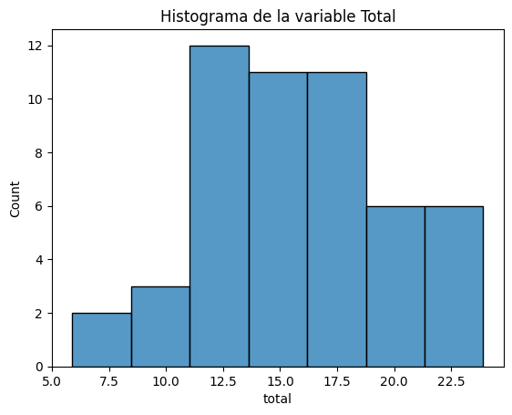

```python
sns.histplot(data = data, x="total")
plt.title("Histograma de la variable Total")
plt.savefig("histograma.png", dpi=300)
plt.show()
```